# Practical Machine Learning - Course Project

@faizanshaytan

6/11/2017

## Practical Machine Learning Project | Prediction Assignment Writeup

### I. Overview

This project is the basis for the final Peer Assessment project from the *Practical Machine Learning* course through Coursera’s Data Science focus.

The project was configured on OSX using RStudio to create this project writeup as a html file. This can also be easily made into a PDF since the knitr functionality is quite powerful. Moreover, using the prediction models developed while completing this project, one must also use the model to complete course quiz.

### II. Background

Using devices such as Jawbone Up, Nike FuelBand, and Fitbit it is now possible to collect a large amount of data about personal activity relatively inexpensively. These type of devices are part of the quantified self movement - a group of enthusiasts who take measurements about themselves regularly to improve their health, to find patterns in their behavior, or because they are tech geeks. One thing that people regularly do is quantify how much of a particular activity they do, but they rarely quantify how well they do it. In this project, your goal will be to use data from accelerometers on the belt, forearm, arm, and dumbell of 6 participants. They were asked to perform barbell lifts correctly and incorrectly in 5 different ways. More information is available from the website here: http://groupware.les.inf.puc-rio.br/har (see the section on the Weight Lifting Exercise Dataset).

#### Data

The training data for this project are available here: https://d396qusza40orc.cloudfront.net/predmachlearn/pml-training.csv

The test data are available here: https://d396qusza40orc.cloudfront.net/predmachlearn/pml-testing.csv

More information regarding the source can be found here: http://groupware.les.inf.puc-rio.br/har.

### III.1 | Setup for Environment (loading of libraries required)

```r
library(e1071)
library(knitr)
library(caret)
```

```r
library(rpart)
library(rpart.plot)
library(ggplot2)
library(randomForest)
```

### III.2 | Loading Data

```r
URLtraining <- "https://d396qusza40orc.cloudfront.net/predmachlearn/pml-training.csv"
URLtesting <- "https://d396qusza40orc.cloudfront.net/predmachlearn/pml-testing.csv"

training <- read.csv(url(URLtraining), na.strings = c("", "NA", "#DIV0!"))
testing <- read.csv(url(URLtesting), na.strings = c("", "NA", "#DIV0!"))
```

We need to ensure that “classe” is not included into testing data set, so define the same columns

```r
copyColumnName <- colnames(training) == colnames(testing)
colnames(training)[copyColumnName==FALSE]
```

```
## [1] "classe"
```

### III.3 | Checking Data Cleanup

```r
training<-training[,colSums(is.na(training)) == 0]
testing <-testing[,colSums(is.na(testing)) == 0]
```

### III.4 | Checking Column Names of Training Dataset

```r
head(colnames(training))
```

```
## [1] "X"                    "user_name"            "raw_timestamp_part_1"
## [4] "raw_timestamp_part_2" "cvtd_timestamp"       "new_window"
```

7 variables from the begining of the training data was removed since they are irrelevant to prediction.

```r
training <- training[,8:dim(training)[2]]
testing <- testing[,8:dim(testing)[2]]
```

### IV.1 | Training, Testing & Data Validation

The training dataset was separated into three parts: * tranining (60%) * testing (20%) * validation (20%)

```r
set.seed(123)

seed_data1 <- createDataPartition(y = training$classe, p = 0.8, list = F)
seed_data2 <- training[seed_data1,]

validation <- training[-seed_data1,]

training_data1 <- createDataPartition(y = seed_data2$classe, p = 0.75, list = F)
training_data2 <- seed_data2[training_data1,]

test_data <- seed_data2[-training_data1,]
```

Plot of *classe*:

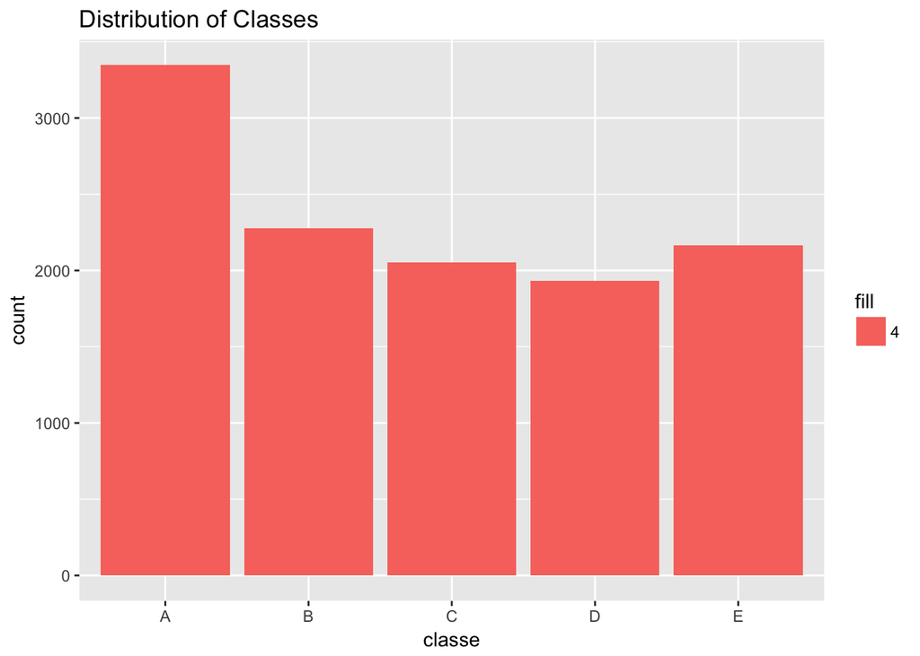

```r
qplot(classe,
      data = training_data2,
      main = "Distribution of Classes",
      fill = "4"
      )
```

### IV.2 | These are the Predictors of the Data Set:

```r
names(training_data2[,-53])
```

```
##  [1] "roll_belt"            "pitch_belt"           "yaw_belt"
##  [4] "total_accel_belt"     "gyros_belt_x"         "gyros_belt_y"
##  [7] "gyros_belt_z"         "accel_belt_x"         "accel_belt_y"
## [10] "accel_belt_z"         "magnet_belt_x"        "magnet_belt_y"
## [13] "magnet_belt_z"        "roll_arm"             "pitch_arm"
## [16] "yaw_arm"              "total_accel_arm"      "gyros_arm_x"
## [19] "gyros_arm_y"          "gyros_arm_z"          "accel_arm_x"
## [22] "accel_arm_y"          "accel_arm_z"          "magnet_arm_x"
## [25] "magnet_arm_y"         "magnet_arm_z"         "roll_dumbbell"
## [28] "pitch_dumbbell"       "yaw_dumbbell"         "total_accel_dumbbell"
## [31] "gyros_dumbbell_x"     "gyros_dumbbell_y"     "gyros_dumbbell_z"
## [34] "accel_dumbbell_x"     "accel_dumbbell_y"     "accel_dumbbell_z"
## [37] "magnet_dumbbell_x"    "magnet_dumbbell_y"    "magnet_dumbbell_z"
## [40] "roll_forearm"         "pitch_forearm"        "yaw_forearm"
## [43] "total_accel_forearm"  "gyros_forearm_x"      "gyros_forearm_y"
## [46] "gyros_forearm_z"      "accel_forearm_x"      "accel_forearm_y"
## [49] "accel_forearm_z"      "magnet_forearm_x"     "magnet_forearm_y"
## [52] "magnet_forearm_z"
```

### V.1 | Prediction Model: Decision Tree Model

```r
model_tree <- rpart(classe ~ ., data=training_data2, method="class")
prediction_tree <- predict(model_tree, test_data, type="class")
class_tree <- confusionMatrix(prediction_tree, test_data$classe)
class_tree
```

```
## Confusion Matrix and Statistics
##
##           Reference
## Prediction   A   B   C   D   E
##          A 944 111   7  53  42
##          B  53 492  51  59  53
##          C  49  98 447  54  51
##          D  47  33 178 468  70
##          E  23  25   1   9 505
##
## Overall Statistics
##
##                Accuracy : 0.728
##                  95% CI : (0.7138, 0.7419)
##     No Information Rate : 0.2845
##     P-Value [Acc > NIR] : < 2.2e-16
##
##                   Kappa : 0.6559
##  Mcnemar's Test P-Value : < 2.2e-16
##
## Statistics by Class:
##
##                      Class: A Class: B Class: C Class: D Class: E
## Sensitivity            0.8459   0.6482   0.6535   0.7278   0.7004
## Specificity            0.9241   0.9317   0.9222   0.9000   0.9819
## Pos Pred Value         0.8159   0.6949   0.6395   0.5879   0.8970
## Neg Pred Value         0.9378   0.9170   0.9265   0.9440   0.9357
## Prevalence             0.2845   0.1935   0.1744   0.1639   0.1838
## Detection Rate         0.2406   0.1254   0.1139   0.1193   0.1287
## Detection Prevalence   0.2949   0.1805   0.1782   0.2029   0.1435
## Balanced Accuracy      0.8850   0.7900   0.7879   0.8139   0.8412
```

### V.2 | Checking the Decision Tree Model (model_tree)

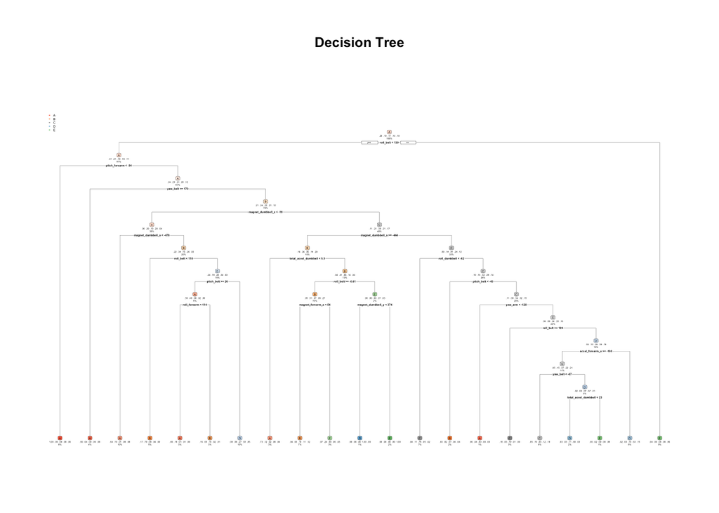

```r
rpart.plot(model_tree, main = "Decision Tree", under = T, faclen = 0)
```

### V.3 | Prediction Model: Random Forest Model

```r
forest_model <- randomForest(classe ~ ., data=training_data2, method="class")
prediction_forest <- predict(forest_model, test_data, type="class")
random_forest <- confusionMatrix(prediction_forest, test_data$classe)
random_forest
```

```
## Confusion Matrix and Statistics
##
##           Reference
## Prediction    A    B    C    D    E
##          A 1116    2    0    0    0
##          B    0  753    5    0    0
##          C    0    3  677    9    0
##          D    0    1    2  634    2
##          E    0    0    0    0  719
##
## Overall Statistics
##
##                Accuracy : 0.9939
##                  95% CI : (0.9909, 0.9961)
##     No Information Rate : 0.2845
##     P-Value [Acc > NIR] : < 2.2e-16
##
##                   Kappa : 0.9923
##  Mcnemar's Test P-Value : NA
##
## Statistics by Class:
##
##                      Class: A Class: B Class: C Class: D Class: E
## Sensitivity            1.0000   0.9921   0.9898   0.9860   0.9972
## Specificity            0.9993   0.9984   0.9963   0.9985   1.0000
## Pos Pred Value         0.9982   0.9934   0.9826   0.9922   1.0000
## Neg Pred Value         1.0000   0.9981   0.9978   0.9973   0.9994
## Prevalence             0.2845   0.1935   0.1744   0.1639   0.1838
## Detection Rate         0.2845   0.1919   0.1726   0.1616   0.1833
## Detection Prevalence   0.2850   0.1932   0.1756   0.1629   0.1833
## Balanced Accuracy      0.9996   0.9953   0.9930   0.9922   0.9986
```

*Prediction Algorithm and Confusion Matrix*

```r
prediction1 <- predict(forest_model, newdata=test_data, type="class")
confusionMatrix(prediction1, test_data$classe)
```

```
## Confusion Matrix and Statistics
##
##           Reference
## Prediction    A    B    C    D    E
##          A 1116    2    0    0    0
##          B    0  753    5    0    0
##          C    0    3  677    9    0
##          D    0    1    2  634    2
##          E    0    0    0    0  719
##
## Overall Statistics
##
##                Accuracy : 0.9939
##                  95% CI : (0.9909, 0.9961)
##     No Information Rate : 0.2845
##     P-Value [Acc > NIR] : < 2.2e-16
##
##                   Kappa : 0.9923
##  Mcnemar's Test P-Value : NA
##
## Statistics by Class:
##
##                      Class: A Class: B Class: C Class: D Class: E
## Sensitivity            1.0000   0.9921   0.9898   0.9860   0.9972
## Specificity            0.9993   0.9984   0.9963   0.9985   1.0000
## Pos Pred Value         0.9982   0.9934   0.9826   0.9922   1.0000
## Neg Pred Value         1.0000   0.9981   0.9978   0.9973   0.9994
## Prevalence             0.2845   0.1935   0.1744   0.1639   0.1838
## Detection Rate         0.2845   0.1919   0.1726   0.1616   0.1833
## Detection Prevalence   0.2850   0.1932   0.1756   0.1629   0.1833
## Balanced Accuracy      0.9996   0.9953   0.9930   0.9922   0.9986
```

The Random Forest Model created in Section V.3 is a significantly better predictive model than the Decision Tree Model created in V.1-V.2. The Random Forest Model has a greater accuracy of 0.9939 as opposed to the Decision Tree with has an accuracy of 0.728, also meaning that considering more predictors for the model would be superfluous.

### VI | Project Conclusions

Ultimately, the data led us to believe that the Random Forest Model (*99.39%*) has a much greater accuracy than the Decision Tree Model (*72.8%*)